# Project 2

## Introduction

> In this project I'll explore "Soccer Database", which contains differnt tables with data about top european leagues teams, matches and player, in the period of season 2008/2009 to season 2015/2016. The dataset was provided in SQLite format and have been checked in DB browser, and later on imported and extracted into python by "sqlalchemy" library.

#### By the end of the project the following questions should be answered :

1. Oldest players
2. Youngest players
3. Shortest players
4. Tallest players
5. Best rated players
6. Best potential rated players
7. Players with most appearances
8. Team scored most goals in a single season
9. Team scored most goals
10. Total number of goals for each season
11. Total number of goals for each League
12. What teams improved the most over the time period?
13. What team attributes lead to the most victories?
14. Relation between home and away wins
15. Team with most wins
16. Team with most away wins
17. Team with most home wins

## Importing libraries

### Importing data and converting sqlite files to CSV

```python
import pandas as pd
import numpy as np
import matplotlib.pyplot as plt
import seaborn as sns
from sqlalchemy import create_engine
from IPython.display import Image
%matplotlib inline
```

#### Extract tables from 'sqlite' dataframe

#### Then saving extracted tables into differnt CSV table to use later

```python
engine = create_engine('sqlite:///database.sqlite')
engine.table_names()
```

```
['Country',
 'League',
 'Match',
 'Player',
 'Player_Attributes',
 'Team',
 'Team_Attributes',
 'sqlite_sequence']
```

```python
conn = engine.connect()
```

```python
country = pd.read_sql_query('SELECT * FROM Country', engine)
country.to_csv('country.csv', index=False)
```

```python
league = pd.read_sql_query('SELECT * FROM League', engine)
league.to_csv('league.csv', index=False)
```

```python
match = pd.read_sql_query('SELECT * FROM Match', engine)
match.to_csv('match.csv', index=False)
```

```python
player = pd.read_sql_query('SELECT * FROM Player', engine)
player.to_csv('player.csv', index=False)
```

```python
player_attributes = pd.read_sql_query('SELECT * FROM Player_Attributes', engine)
player_attributes.to_csv('player_attributes.csv', index=False)
```

```python
team = pd.read_sql_query('SELECT * FROM Team', engine)
team.to_csv('team.csv', index=False)
```

```python
team_attributes = pd.read_sql_query('SELECT * FROM Team_Attributes', engine)
team_attributes.to_csv('team_attributes.csv', index=False)
```

# Data wrangling & Exploratory data analysis

## Players

```python
player = pd.read_csv('player.csv')
player.head()
```

|  | id | player_api_id | player_name | player_fifa_api_id | birthday | height | weight |
| --- | --- | --- | --- | --- | --- | --- | --- |
| 0 | 1 | 505942 | Aaron Appindangoye | 218353 | 1992-02-29 00:00:00 | 182.88 | 187 |
| 1 | 2 | 155782 | Aaron Cresswell | 189615 | 1989-12-15 00:00:00 | 170.18 | 146 |
| 2 | 3 | 162549 | Aaron Doran | 186170 | 1991-05-13 00:00:00 | 170.18 | 163 |
| 3 | 4 | 30572 | Aaron Galindo | 140161 | 1982-05-08 00:00:00 | 182.88 | 198 |
| 4 | 5 | 23780 | Aaron Hughes | 17725 | 1979-11-08 00:00:00 | 182.88 | 154 |

```python
df_player = player.copy()
df_player.info()
```

```
<class 'pandas.core.frame.DataFrame'>
RangeIndex: 11060 entries, 0 to 11059
Data columns (total 7 columns):
 #   Column              Non-Null Count  Dtype
---  ------              --------------  -----
 0   id                  11060 non-null  int64
 1   player_api_id       11060 non-null  int64
 2   player_name         11060 non-null  object
 3   player_fifa_api_id  11060 non-null  int64
 4   birthday            11060 non-null  object
 5   height              11060 non-null  float64
 6   weight              11060 non-null  int64
dtypes: float64(1), int64(4), object(2)
memory usage: 605.0+ KB
```

#### Table has no Na values and datatypes of the columns are the right type except for the birthday which is a string and will convert it to datetime format and drop 'player_fifa_api_id' column because we don't need it for our analysis

```python
df_player.drop('player_fifa_api_id', axis = 1, inplace = True)
df_player['birthday'] = pd.to_datetime(df_player['birthday'], format = '%Y-%m-%d')
```

```python
df_player.head()
```

|  | id | player_api_id | player_name | birthday | height | weight |
| --- | --- | --- | --- | --- | --- | --- |
| 0 | 1 | 505942 | Aaron Appindangoye | 1992-02-29 | 182.88 | 187 |
| 1 | 2 | 155782 | Aaron Cresswell | 1989-12-15 | 170.18 | 146 |
| 2 | 3 | 162549 | Aaron Doran | 1991-05-13 | 170.18 | 163 |
| 3 | 4 | 30572 | Aaron Galindo | 1982-05-08 | 182.88 | 198 |
| 4 | 5 | 23780 | Aaron Hughes | 1979-11-08 | 182.88 | 154 |

##### Create 4 different tables for oldest, youngest, shortest, tallest players and droping columns not going to use in the findings

```python
oldest_player = df_player.sort_values(by = 'birthday').head(10)
oldest_player.drop(['id','player_api_id','weight', 'height'], axis = 1, inplace = True)
oldest_player.to_csv('oldest_player.csv', index=False)

youngest_player = df_player.sort_values(by = 'birthday', ascending = False).head(10)
youngest_player.drop(['id','player_api_id','weight', 'height'], axis = 1, inplace = True)
youngest_player.to_csv('youngest_player.csv', index=False)

shortest_player = df_player.sort_values(by = 'height').head(10)
shortest_player.drop(['id','player_api_id','weight', 'birthday'], axis = 1, inplace = True)
shortest_player.to_csv('shortest_player.csv', index=False)

tallest_player = df_player.sort_values(by = 'height', ascending = False).head(10)
tallest_player.drop(['id','player_api_id','weight', 'birthday'], axis = 1, inplace = True)
tallest_player.to_csv('tallest_player.csv', index=False)
```

## Find the oldest players

> With the oldest player in the list *'Alberto Fontana'*

```python
oldest_player
```

|  | player_name | birthday |
| --- | --- | --- |
| 289 | Alberto Fontana | 1967-01-23 |
| 8284 | Paolo Maldini | 1968-06-26 |
| 8993 | Rob van Dijk | 1969-01-15 |
| 6238 | Luca Bucci | 1969-03-13 |
| 2492 | Dean Windass | 1969-04-01 |
| 3452 | Francesco Antonioli | 1969-09-14 |
| 7389 | Michael Tarnat | 1969-10-27 |
| 4827 | Jens Lehmann | 1969-11-10 |
| 4122 | Hans Vonk | 1970-01-30 |
| 2429 | David Weir | 1970-05-10 |

## Find the youngest players

> With the youngest player in the list *'Jonathan Leko'*

```python
youngest_player
```

|  | player_name | birthday |
| --- | --- | --- |
| 5176 | Jonathan Leko | 1999-04-24 |
| 3823 | Gianluigi Donnarumma | 1999-02-25 |
| 271 | Alban Lafont | 1999-01-23 |
| 5947 | Kylian Mbappe Lottin | 1998-12-20 |
| 8826 | Reece Oxford | 1998-12-16 |
| 4139 | Harry Souttar | 1998-10-22 |
| 1768 | Christian Pulisic | 1998-09-18 |
| 5152 | Jonatan Montiel | 1998-09-03 |
| 10356 | Tom Davies | 1998-06-30 |
| 9198 | Ronael Pierre-Gabriel | 1998-06-13 |

# Find the shortest player

#### A table been created with the shortest 10 players based on their reported height

> With the shortest player in the list *'Juan Quero'*

```python
shortest_player
```

|  | player_name | height |
| --- | --- | --- |
| 5446 | Juan Quero | 157.48 |
| 2609 | Diego Buonanotte | 160.02 |
| 7247 | Maxi Moralez | 160.02 |
| 2853 | Edgar Salli | 162.56 |
| 9427 | Samuel Asamoah | 162.56 |
| 3442 | Fouad Rachid | 162.56 |
| 8672 | Quentin Othon | 162.56 |
| 829 | Anthony Deroin | 162.56 |
| 1081 | Bakari Kone | 162.56 |
| 8251 | Pablo Piatti | 162.56 |

# Find the tallest player

#### A table been created with the tallest 10 players based on their reported height

> With the tallest player in the list *'Kristof van Hout'*

```python
tallest_player
```

|  | player_name | height |
| --- | --- | --- |
| 5901 | Kristof van Hout | 208.28 |
| 8004 | Nikola Zigic | 203.20 |
| 5950 | Lacina Traore | 203.20 |
| 10558 | Vanja Milinkovic-Savic | 203.20 |
| 1298 | Bogdan Milic | 203.20 |
| 3270 | Fejsal Mulic | 203.20 |
| 5797 | Kevin Vink | 203.20 |
| 8273 | Paolo Acerbis | 203.20 |
| 11027 | Zeljko Kalac | 203.20 |
| 1923 | Costel Pantilimon | 203.20 |

```python
player_attributes = pd.read_csv('player_attributes.csv')
player_attributes.head()
```

|  | id | player_fifa_api_id | player_api_id | date | overall_rating | potential | preferred_foot | attacking_work_rate | defensive_work_rate | crossing | ... | vision | penalties | marking | standing_tackle | sliding_tackle | gk_diving | gk_handling | gk_kicking | gk_positioning | gk_reflexes |
| --- | --- | --- | --- | --- | --- | --- | --- | --- | --- | --- | --- | --- | --- | --- | --- | --- | --- | --- | --- | --- | --- |
| 0 | 1 | 218353 | 505942 | 2016-02-18 00:00:00 | 67.0 | 71.0 | right | medium | medium | 49.0 | ... | 54.0 | 48.0 | 65.0 | 69.0 | 69.0 | 6.0 | 11.0 | 10.0 | 8.0 | 8.0 |
| 1 | 2 | 218353 | 505942 | 2015-11-19 00:00:00 | 67.0 | 71.0 | right | medium | medium | 49.0 | ... | 54.0 | 48.0 | 65.0 | 69.0 | 69.0 | 6.0 | 11.0 | 10.0 | 8.0 | 8.0 |
| 2 | 3 | 218353 | 505942 | 2015-09-21 00:00:00 | 62.0 | 66.0 | right | medium | medium | 49.0 | ... | 54.0 | 48.0 | 65.0 | 66.0 | 69.0 | 6.0 | 11.0 | 10.0 | 8.0 | 8.0 |
| 3 | 4 | 218353 | 505942 | 2015-03-20 00:00:00 | 61.0 | 65.0 | right | medium | medium | 48.0 | ... | 53.0 | 47.0 | 62.0 | 63.0 | 66.0 | 5.0 | 10.0 | 9.0 | 7.0 | 7.0 |
| 4 | 5 | 218353 | 505942 | 2007-02-22 00:00:00 | 61.0 | 65.0 | right | medium | medium | 48.0 | ... | 53.0 | 47.0 | 62.0 | 63.0 | 66.0 | 5.0 | 10.0 | 9.0 | 7.0 | 7.0 |

5 rows × 42 columns

```python
player_attributes.info()
```

```
<class 'pandas.core.frame.DataFrame'>
RangeIndex: 183978 entries, 0 to 183977
Data columns (total 42 columns):
 #   Column               Non-Null Count   Dtype
---  ------               --------------   -----
 0   id                   183978 non-null  int64
 1   player_fifa_api_id   183978 non-null  int64
 2   player_api_id        183978 non-null  int64
 3   date                 183978 non-null  object
 4   overall_rating       183142 non-null  float64
 5   potential            183142 non-null  float64
 6   preferred_foot       183142 non-null  object
 7   attacking_work_rate  180748 non-null  object
 8   defensive_work_rate  183142 non-null  object
 9   crossing             183142 non-null  float64
```

[output cut: 34 more lines]

```python
player_attributes_1 = player_attributes[['player_api_id','overall_rating','potential']]
player_attributes_1
```

|  | player_api_id | overall_rating | potential |
| --- | --- | --- | --- |
| 0 | 505942 | 67.0 | 71.0 |
| 1 | 505942 | 67.0 | 71.0 |
| 2 | 505942 | 62.0 | 66.0 |
| 3 | 505942 | 61.0 | 65.0 |
| 4 | 505942 | 61.0 | 65.0 |
| ... | ... | ... | ... |
| 183973 | 39902 | 83.0 | 85.0 |
| 183974 | 39902 | 78.0 | 80.0 |
| 183975 | 39902 | 77.0 | 80.0 |
| 183976 | 39902 | 78.0 | 81.0 |
| 183977 | 39902 | 80.0 | 81.0 |

183978 rows × 3 columns

```python
player_attributes_1.info()
```

```
<class 'pandas.core.frame.DataFrame'>
RangeIndex: 183978 entries, 0 to 183977
Data columns (total 3 columns):
 #   Column          Non-Null Count   Dtype
---  ------          --------------   -----
 0   player_api_id   183978 non-null  int64
 1   overall_rating  183142 non-null  float64
 2   potential       183142 non-null  float64
dtypes: float64(2), int64(1)
memory usage: 4.2 MB
```

```python
df_player.drop(['id','birthday','height','weight'], axis = 1, inplace = True)
df_player
```

|  | player_api_id | player_name |
| --- | --- | --- |
| 0 | 505942 | Aaron Appindangoye |
| 1 | 155782 | Aaron Cresswell |
| 2 | 162549 | Aaron Doran |
| 3 | 30572 | Aaron Galindo |
| 4 | 23780 | Aaron Hughes |
| ... | ... | ... |
| 11055 | 26357 | Zoumana Camara |
| 11056 | 111182 | Zsolt Laczko |
| 11057 | 36491 | Zsolt Low |
| 11058 | 35506 | Zurab Khizanishvili |
| 11059 | 39902 | Zvjezdan Misimovic |

11060 rows × 2 columns

> We drop 4 more coulmns from copied player table because we are done with them for now and only need player name and ID to use it later to merge with other tables

```python
player_attributes_1 = pd.merge(left=df_player, right=player_attributes_1, left_on='player_api_id', right_on='player_api_id')
player_attributes_1
```

|  | player_api_id | player_name | overall_rating | potential |
| --- | --- | --- | --- | --- |
| 0 | 505942 | Aaron Appindangoye | 67.0 | 71.0 |
| 1 | 505942 | Aaron Appindangoye | 67.0 | 71.0 |
| 2 | 505942 | Aaron Appindangoye | 62.0 | 66.0 |
| 3 | 505942 | Aaron Appindangoye | 61.0 | 65.0 |
| 4 | 505942 | Aaron Appindangoye | 61.0 | 65.0 |
| ... | ... | ... | ... | ... |
| 183973 | 39902 | Zvjezdan Misimovic | 83.0 | 85.0 |
| 183974 | 39902 | Zvjezdan Misimovic | 78.0 | 80.0 |
| 183975 | 39902 | Zvjezdan Misimovic | 77.0 | 80.0 |
| 183976 | 39902 | Zvjezdan Misimovic | 78.0 | 81.0 |
| 183977 | 39902 | Zvjezdan Misimovic | 80.0 | 81.0 |

183978 rows × 4 columns

```python
player_attributes_1.drop('player_api_id', axis = 1, inplace = True)
player_attributes_1 = round(player_attributes_1.groupby('player_name').mean('overall_rating'), 2)
player_attributes_1
```

| player_name | overall_rating | potential |
| --- | --- | --- |
| Aaron Appindangoye | 63.60 | 67.60 |
| Aaron Cresswell | 66.97 | 74.48 |
| Aaron Doran | 67.00 | 74.19 |
| Aaron Galindo | 69.09 | 70.78 |
| Aaron Hughes | 73.24 | 74.68 |
| ... | ... | ... |
| Zsolt Low | 67.57 | 72.86 |
| Zurab Khizanishvili | 70.75 | 78.12 |
| Zvjezdan Misimovic | 80.00 | 81.70 |
| de Oliveira Cleber Monteiro | 66.11 | 67.56 |
| dos Santos Fabio Junior | 66.75 | 73.00 |

10848 rows × 2 columns

> We drop player Id columns because we are not going to need it for our analysis and round up the average rating and potential to 2 decimal places for convenience.

```python
top_players = player_attributes_1.sort_values(by = 'overall_rating', ascending = False). head(10)
top_players.to_csv('top_players.csv')

top_players_potential = player_attributes_1.sort_values(by = 'potential', ascending = False). head(10)
top_players.to_csv('top_players.csv')
```

# Top players with the best average overall rating

#### A table been created with the best rated 10 players based on their average performance

> With the best player in the list *'Lionel Messi'* with average rating 92.19

```python
top_players
```

| player_name | overall_rating | potential |
| --- | --- | --- |
| Lionel Messi | 92.19 | 95.23 |
| Cristiano Ronaldo | 91.28 | 93.48 |
| Franck Ribery | 88.46 | 89.92 |
| Andres Iniesta | 88.32 | 90.56 |
| Zlatan Ibrahimovic | 88.29 | 90.05 |
| Arjen Robben | 87.84 | 88.60 |
| Xavi Hernandez | 87.64 | 88.36 |
| Wayne Rooney | 87.22 | 87.94 |
| Iker Casillas | 86.95 | 88.23 |
| Philipp Lahm | 86.73 | 87.53 |

# Top players with the best average potential rating

#### A table been created with the best potential rating 10 players based on their average performance

> With the best player in the list *'Lionel Messi'* with average potential rating 95.23

```python
top_players_potential
```

| player_name | overall_rating | potential |
| --- | --- | --- |
| Lionel Messi | 92.19 | 95.23 |
| Cristiano Ronaldo | 91.28 | 93.48 |
| Fabio Cannavaro | 85.17 | 90.83 |
| Neymar | 83.80 | 90.76 |
| Andres Iniesta | 88.32 | 90.56 |
| Mario Goetze | 83.18 | 90.15 |
| Zlatan Ibrahimovic | 88.29 | 90.05 |
| Roy Makaay | 78.33 | 90.00 |
| James Rodriguez | 83.00 | 89.95 |
| Franck Ribery | 88.46 | 89.92 |

```python
match = pd.read_csv('match.csv')
match.head()
```

|  | id | country_id | league_id | season | stage | date | match_api_id | home_team_api_id | away_team_api_id | home_team_goal | ... | SJA | VCH | VCD | VCA | GBH | GBD | GBA | BSH | BSD | BSA |
| --- | --- | --- | --- | --- | --- | --- | --- | --- | --- | --- | --- | --- | --- | --- | --- | --- | --- | --- | --- | --- | --- |
| 0 | 1 | 1 | 1 | 2008/2009 | 1 | 2008-08-17 00:00:00 | 492473 | 9987 | 9993 | 1 | ... | 4.00 | 1.65 | 3.40 | 4.50 | 1.78 | 3.25 | 4.00 | 1.73 | 3.40 | 4.20 |
| 1 | 2 | 1 | 1 | 2008/2009 | 1 | 2008-08-16 00:00:00 | 492474 | 10000 | 9994 | 0 | ... | 3.80 | 2.00 | 3.25 | 3.25 | 1.85 | 3.25 | 3.75 | 1.91 | 3.25 | 3.60 |
| 2 | 3 | 1 | 1 | 2008/2009 | 1 | 2008-08-16 00:00:00 | 492475 | 9984 | 8635 | 0 | ... | 2.50 | 2.35 | 3.25 | 2.65 | 2.50 | 3.20 | 2.50 | 2.30 | 3.20 | 2.75 |
| 3 | 4 | 1 | 1 | 2008/2009 | 1 | 2008-08-17 00:00:00 | 492476 | 9991 | 9998 | 5 | ... | 7.50 | 1.45 | 3.75 | 6.50 | 1.50 | 3.75 | 5.50 | 1.44 | 3.75 | 6.50 |
| 4 | 5 | 1 | 1 | 2008/2009 | 1 | 2008-08-16 00:00:00 | 492477 | 7947 | 9985 | 1 | ... | 1.73 | 4.50 | 3.40 | 1.65 | 4.50 | 3.50 | 1.65 | 4.75 | 3.30 | 1.67 |

5 rows × 115 columns

```python
match.columns
```

```
Index(['id', 'country_id', 'league_id', 'season', 'stage', 'date',
       'match_api_id', 'home_team_api_id', 'away_team_api_id',
       'home_team_goal',
       ...
       'SJA', 'VCH', 'VCD', 'VCA', 'GBH', 'GBD', 'GBA', 'BSH', 'BSD', 'BSA'],
      dtype='object', length=115)
```

> Match table have 115 coulmns we can't do analysis on that much coulmns at the same time, so we only choose coulmns we going to need for the next analysis which is players id in starting 11 in home and away teams and make a copy of that table to use then check if the table has NaN and drop them if their is any, then reshape the table from wide table to long table for our next analysis, then drop another column we created during melting the table and rename the column for convenience and prepare it for next merging step

```python
match_players = match[['home_player_1', 'home_player_2', 'home_player_3',
       'home_player_4', 'home_player_5', 'home_player_6', 'home_player_7',
       'home_player_8', 'home_player_9', 'home_player_10', 'home_player_11',
       'away_player_1', 'away_player_2', 'away_player_3', 'away_player_4',
       'away_player_5', 'away_player_6', 'away_player_7', 'away_player_8',
       'away_player_9', 'away_player_10', 'away_player_11']]
match_players
```

|  | home_player_1 | home_player_2 | home_player_3 | home_player_4 | home_player_5 | home_player_6 | home_player_7 | home_player_8 | home_player_9 | home_player_10 | ... | away_player_2 | away_player_3 | away_player_4 | away_player_5 | away_player_6 | away_player_7 | away_player_8 | away_player_9 | away_player_10 | away_player_11 |
| --- | --- | --- | --- | --- | --- | --- | --- | --- | --- | --- | --- | --- | --- | --- | --- | --- | --- | --- | --- | --- | --- |
| 0 | NaN | NaN | NaN | NaN | NaN | NaN | NaN | NaN | NaN | NaN | ... | NaN | NaN | NaN | NaN | NaN | NaN | NaN | NaN | NaN | NaN |
| 1 | NaN | NaN | NaN | NaN | NaN | NaN | NaN | NaN | NaN | NaN | ... | NaN | NaN | NaN | NaN | NaN | NaN | NaN | NaN | NaN | NaN |
| 2 | NaN | NaN | NaN | NaN | NaN | NaN | NaN | NaN | NaN | NaN | ... | NaN | NaN | NaN | NaN | NaN | NaN | NaN | NaN | NaN | NaN |
| 3 | NaN | NaN | NaN | NaN | NaN | NaN | NaN | NaN | NaN | NaN | ... | NaN | NaN | NaN | NaN | NaN | NaN | NaN | NaN | NaN | NaN |
| 4 | NaN | NaN | NaN | NaN | NaN | NaN | NaN | NaN | NaN | NaN | ... | NaN | NaN | NaN | NaN | NaN | NaN | NaN | NaN | NaN | NaN |
| ... | ... | ... | ... | ... | ... | ... | ... | ... | ... | ... | ... | ... | ... | ... | ... | ... | ... | ... | ... | ... | ... |
| 25974 | 42231.0 | 678384.0 | 95220.0 | 638592.0 | 413155.0 | 45780.0 | 171229.0 | 67333.0 | 119839.0 | 143790.0 | ... | 563066.0 | 8800.0 | 67304.0 | 158253.0 | 133126.0 | 186524.0 | 93223.0 | 121115.0 | 232110.0 | 289732.0 |
| 25975 | 33272.0 | 41621.0 | 25813.0 | 257845.0 | 114735.0 | 42237.0 | 113227.0 | 358156.0 | 32343.0 | 531309.0 | ... | 114792.0 | 150007.0 | 178119.0 | 27232.0 | 570830.0 | 260708.0 | 201704.0 | 36382.0 | 34082.0 | 95257.0 |
| 25976 | 157856.0 | 274779.0 | 177689.0 | 294256.0 | 42258.0 | 39979.0 | 173936.0 | 147959.0 | 451983.0 | 80564.0 | ... | 67349.0 | 202663.0 | 32597.0 | 114794.0 | 188114.0 | 25840.0 | 482200.0 | 95230.0 | 451335.0 | 275122.0 |
| 25977 | NaN | 8881.0 | 173534.0 | 39646.0 | 282287.0 | 340790.0 | 393337.0 | 8893.0 | 614454.0 | 93229.0 | ... | 121080.0 | 197757.0 | 260964.0 | 231614.0 | 113235.0 | 41116.0 | 462608.0 | 42262.0 | 92252.0 | 194532.0 |
| 25978 | 274787.0 | 492132.0 | 108451.0 | 25815.0 | 94553.0 | 384376.0 | 598355.0 | 36785.0 | 45174.0 | 302079.0 | ... | 95216.0 | 172768.0 | 22834.0 | 458806.0 | 207234.0 | 25772.0 | 40274.0 | 34035.0 | 41726.0 | 527103.0 |

25979 rows × 22 columns

```python
match_players = match_players.melt()
match_players = match_players.dropna()
match_players.head()
```

|  | variable | value |
| --- | --- | --- |
| 144 | home_player_1 | 39890.0 |
| 145 | home_player_1 | 38327.0 |
| 146 | home_player_1 | 95597.0 |
| 148 | home_player_1 | 30934.0 |
| 149 | home_player_1 | 37990.0 |

```python
match_players.drop('variable', axis = 1, inplace = True)
```

```python
match_players.rename(columns = {'value':'player_id'}, inplace = True)
```

```python
player.drop(['id', 'player_fifa_api_id', 'birthday', 'height', 'weight'], axis = 1, inplace = True)
```

```python
appearance = pd.merge(left=player, right=match_players, left_on='player_api_id', right_on='player_id')
appearance
```

|  | player_api_id | player_name | player_id |
| --- | --- | --- | --- |
| 0 | 505942 | Aaron Appindangoye | 505942.0 |
| 1 | 505942 | Aaron Appindangoye | 505942.0 |
| 2 | 505942 | Aaron Appindangoye | 505942.0 |
| 3 | 505942 | Aaron Appindangoye | 505942.0 |
| 4 | 505942 | Aaron Appindangoye | 505942.0 |
| ... | ... | ... | ... |
| 542276 | 39902 | Zvjezdan Misimovic | 39902.0 |
| 542277 | 39902 | Zvjezdan Misimovic | 39902.0 |
| 542278 | 39902 | Zvjezdan Misimovic | 39902.0 |
| 542279 | 39902 | Zvjezdan Misimovic | 39902.0 |
| 542280 | 39902 | Zvjezdan Misimovic | 39902.0 |

542281 rows × 3 columns

```python
appearance = appearance.groupby('player_name').count().sort_values(by = 'player_api_id',ascending = False)
appearance.drop('player_id', axis = 1,inplace = True)
appearance.rename(columns = {'player_api_id':'apperances'}, inplace = True)
appearance = appearance.head(10)
appearance.to_csv('player_most_appearances.csv')
```

> Merge the player table and modfied match table into one table and count the number of apperances for each player in the least and drop id column because we have the player names now and rename 'player_api_id' column into 'apperances' for readabilty

# Players with most apperances

#### A table been created with 10 players with the most apperances

> With the player with most appearances is *'Marcelo'* with with total of 513 apperances

```python
appearance
```

| player_name | apperances |
| --- | --- |
| Marcelo | 513 |
| Ricardo | 413 |
| Danilo | 350 |
| Gonzalo Castro | 347 |
| Juanfran | 341 |
| Fernando | 326 |
| Diego | 314 |
| Steve Mandanda | 300 |
| Felipe | 300 |
| Stephane Ruffier | 294 |

# Teams

```python
match = pd.read_csv('match.csv')
match.head()
```

|  | id | country_id | league_id | season | stage | date | match_api_id | home_team_api_id | away_team_api_id | home_team_goal | ... | SJA | VCH | VCD | VCA | GBH | GBD | GBA | BSH | BSD | BSA |
| --- | --- | --- | --- | --- | --- | --- | --- | --- | --- | --- | --- | --- | --- | --- | --- | --- | --- | --- | --- | --- | --- |
| 0 | 1 | 1 | 1 | 2008/2009 | 1 | 2008-08-17 00:00:00 | 492473 | 9987 | 9993 | 1 | ... | 4.00 | 1.65 | 3.40 | 4.50 | 1.78 | 3.25 | 4.00 | 1.73 | 3.40 | 4.20 |
| 1 | 2 | 1 | 1 | 2008/2009 | 1 | 2008-08-16 00:00:00 | 492474 | 10000 | 9994 | 0 | ... | 3.80 | 2.00 | 3.25 | 3.25 | 1.85 | 3.25 | 3.75 | 1.91 | 3.25 | 3.60 |
| 2 | 3 | 1 | 1 | 2008/2009 | 1 | 2008-08-16 00:00:00 | 492475 | 9984 | 8635 | 0 | ... | 2.50 | 2.35 | 3.25 | 2.65 | 2.50 | 3.20 | 2.50 | 2.30 | 3.20 | 2.75 |
| 3 | 4 | 1 | 1 | 2008/2009 | 1 | 2008-08-17 00:00:00 | 492476 | 9991 | 9998 | 5 | ... | 7.50 | 1.45 | 3.75 | 6.50 | 1.50 | 3.75 | 5.50 | 1.44 | 3.75 | 6.50 |
| 4 | 5 | 1 | 1 | 2008/2009 | 1 | 2008-08-16 00:00:00 | 492477 | 7947 | 9985 | 1 | ... | 1.73 | 4.50 | 3.40 | 1.65 | 4.50 | 3.50 | 1.65 | 4.75 | 3.30 | 1.67 |

5 rows × 115 columns

> Again with the match table has a lot of columns that we not going to use for analysis so we pick only the columns we going to need and check data types of the columns and if they have any NaN

```python
goal = match[['league_id','season', 'home_team_api_id', 'away_team_api_id','home_team_goal', 'away_team_goal']]
goal.head()
```

|  | league_id | season | home_team_api_id | away_team_api_id | home_team_goal | away_team_goal |
| --- | --- | --- | --- | --- | --- | --- |
| 0 | 1 | 2008/2009 | 9987 | 9993 | 1 | 1 |
| 1 | 1 | 2008/2009 | 10000 | 9994 | 0 | 0 |
| 2 | 1 | 2008/2009 | 9984 | 8635 | 0 | 3 |
| 3 | 1 | 2008/2009 | 9991 | 9998 | 5 | 0 |
| 4 | 1 | 2008/2009 | 7947 | 9985 | 1 | 3 |

```python
goal.info()
```

```
<class 'pandas.core.frame.DataFrame'>
RangeIndex: 25979 entries, 0 to 25978
Data columns (total 6 columns):
 #   Column            Non-Null Count  Dtype
---  ------            --------------  -----
 0   league_id         25979 non-null  int64
 1   season            25979 non-null  object
 2   home_team_api_id  25979 non-null  int64
 3   away_team_api_id  25979 non-null  int64
 4   home_team_goal    25979 non-null  int64
 5   away_team_goal    25979 non-null  int64
dtypes: int64(5), object(1)
memory usage: 1.2+ MB
```

```python
team = pd.read_csv('team.csv')
team.head()
```

|  | id | team_api_id | team_fifa_api_id | team_long_name | team_short_name |
| --- | --- | --- | --- | --- | --- |
| 0 | 1 | 9987 | 673.0 | KRC Genk | GEN |
| 1 | 2 | 9993 | 675.0 | Beerschot AC | BAC |
| 2 | 3 | 10000 | 15005.0 | SV Zulte-Waregem | ZUL |
| 3 | 4 | 9994 | 2007.0 | Sporting Lokeren | LOK |
| 4 | 5 | 9984 | 1750.0 | KSV Cercle Brugge | CEB |

> With the team table we only need the team id and name so we drop the rest and check data type of the columns and check if their is any Nan's

```python
team.drop(['id','team_fifa_api_id','team_short_name'],axis = 1, inplace = True)
team.head()
```

|  | team_api_id | team_long_name |
| --- | --- | --- |
| 0 | 9987 | KRC Genk |
| 1 | 9993 | Beerschot AC |
| 2 | 10000 | SV Zulte-Waregem |
| 3 | 9994 | Sporting Lokeren |
| 4 | 9984 | KSV Cercle Brugge |

```python
team.info()
```

```
<class 'pandas.core.frame.DataFrame'>
RangeIndex: 299 entries, 0 to 298
Data columns (total 2 columns):
 #   Column          Non-Null Count  Dtype
---  ------          --------------  -----
 0   team_api_id     299 non-null    int64
 1   team_long_name  299 non-null    object
dtypes: int64(1), object(1)
memory usage: 4.8+ KB
```

> For next analysis we going to duplicate the team tables twice(home and away) and rename their coulumns into (home and away columns) to preparete it for merge with match table and and find which team came up winning or a draw, then drop columns from league table that we are not going to use and rename the column into league name for readability then check data type and if the league table have any NaN's and then merged it into the newly created match results table, final drop of unnecessary and repeated coulmns and then rearange the columns for better readability.

```python
home_team = team.copy()
away_team = team.copy()
```

```python
home_team.rename(columns = {'team_api_id' : 'home_team_api_id','team_long_name': 'home_team'}, inplace = True)
away_team.rename(columns = {'team_api_id' : 'away_team_api_id','team_long_name': 'away_team'}, inplace = True)
```

```python
goal_home = pd.merge(left=goal, right=home_team, left_on='home_team_api_id', right_on='home_team_api_id')
```

```python
goal_home_away = pd.merge(left=goal_home, right=away_team, left_on='away_team_api_id', right_on='away_team_api_id')
```

```python
conditions = [goal_home_away['home_team_goal'] > goal_home_away['away_team_goal'],
              goal_home_away['home_team_goal'] < goal_home_away['away_team_goal']]
choices = [goal_home_away['home_team'], goal_home_away['away_team']]
goal_home_away['winner'] = np.select(conditions, choices, default = 'Draw')

goal_home_away.head()
```

|  | league_id | season | home_team_api_id | away_team_api_id | home_team_goal | away_team_goal | home_team | away_team | winner |
| --- | --- | --- | --- | --- | --- | --- | --- | --- | --- |
| 0 | 1 | 2008/2009 | 9987 | 9993 | 1 | 1 | KRC Genk | Beerschot AC | Draw |
| 1 | 1 | 2009/2010 | 9987 | 9993 | 1 | 1 | KRC Genk | Beerschot AC | Draw |
| 2 | 1 | 2010/2011 | 9987 | 9993 | 2 | 1 | KRC Genk | Beerschot AC | KRC Genk |
| 3 | 1 | 2011/2012 | 9987 | 9993 | 3 | 1 | KRC Genk | Beerschot AC | KRC Genk |
| 4 | 1 | 2012/2013 | 9987 | 9993 | 3 | 0 | KRC Genk | Beerschot AC | KRC Genk |

```python
league = pd.read_csv('league.csv')
league.head()
```

|  | id | country_id | name |
| --- | --- | --- | --- |
| 0 | 1 | 1 | Belgium Jupiler League |
| 1 | 1729 | 1729 | England Premier League |
| 2 | 4769 | 4769 | France Ligue 1 |
| 3 | 7809 | 7809 | Germany 1. Bundesliga |
| 4 | 10257 | 10257 | Italy Serie A |

```python
league.drop('id', axis = 1, inplace = True)
league.rename(columns = {'name':'league_name'}, inplace = True)
```

```python
league.info()
```

```
<class 'pandas.core.frame.DataFrame'>
RangeIndex: 11 entries, 0 to 10
Data columns (total 2 columns):
 #   Column       Non-Null Count  Dtype
---  ------       --------------  -----
 0   country_id   11 non-null     int64
 1   league_name  11 non-null     object
dtypes: int64(1), object(1)
memory usage: 304.0+ bytes
```

```python
goal_home_away_league = pd.merge(left=goal_home_away, right=league, left_on='league_id', right_on='country_id')
goal_home_away_league.head()
```

|  | league_id | season | home_team_api_id | away_team_api_id | home_team_goal | away_team_goal | home_team | away_team | winner | country_id | league_name |
| --- | --- | --- | --- | --- | --- | --- | --- | --- | --- | --- | --- |
| 0 | 1 | 2008/2009 | 9987 | 9993 | 1 | 1 | KRC Genk | Beerschot AC | Draw | 1 | Belgium Jupiler League |
| 1 | 1 | 2009/2010 | 9987 | 9993 | 1 | 1 | KRC Genk | Beerschot AC | Draw | 1 | Belgium Jupiler League |
| 2 | 1 | 2010/2011 | 9987 | 9993 | 2 | 1 | KRC Genk | Beerschot AC | KRC Genk | 1 | Belgium Jupiler League |
| 3 | 1 | 2011/2012 | 9987 | 9993 | 3 | 1 | KRC Genk | Beerschot AC | KRC Genk | 1 | Belgium Jupiler League |
| 4 | 1 | 2012/2013 | 9987 | 9993 | 3 | 0 | KRC Genk | Beerschot AC | KRC Genk | 1 | Belgium Jupiler League |

```python
goal_home_away_league.drop(['league_id', 'home_team_api_id', 'away_team_api_id', 'country_id'],axis = 1, inplace = True)
goal_home_away_league = goal_home_away_league.reindex(columns = ['league_name', 'season', 'home_team', 'away_team',
                                                                 'home_team_goal', 'away_team_goal','winner'])
goal_home_away_league.head()
```

|  | league_name | season | home_team | away_team | home_team_goal | away_team_goal | winner |
| --- | --- | --- | --- | --- | --- | --- | --- |
| 0 | Belgium Jupiler League | 2008/2009 | KRC Genk | Beerschot AC | 1 | 1 | Draw |
| 1 | Belgium Jupiler League | 2009/2010 | KRC Genk | Beerschot AC | 1 | 1 | Draw |
| 2 | Belgium Jupiler League | 2010/2011 | KRC Genk | Beerschot AC | 2 | 1 | KRC Genk |
| 3 | Belgium Jupiler League | 2011/2012 | KRC Genk | Beerschot AC | 3 | 1 | KRC Genk |
| 4 | Belgium Jupiler League | 2012/2013 | KRC Genk | Beerschot AC | 3 | 0 | KRC Genk |

```python
team_season_goals = goal_home_away_league.copy()
```

```python
home_goals = team_season_goals[['season','league_name', 'home_team', 'home_team_goal']].groupby(['season','league_name','home_team'], as_index = False)['home_team_goal'].sum().sort_values(by = 'home_team_goal',ascending = False)
away_goals = team_season_goals[['season','league_name', 'away_team', 'away_team_goal']].groupby(['season','league_name','away_team'], as_index = False)['away_team_goal'].sum().sort_values(by = 'away_team_goal',ascending = False)
```

```python
team_season_goals = pd.merge(left=home_goals, right=away_goals, left_on=['home_team','season'], right_on=['away_team','season'])
team_season_goals.head()
```

|  | season | league_name_x | home_team | home_team_goal | league_name_y | away_team | away_team_goal |
| --- | --- | --- | --- | --- | --- | --- | --- |
| 0 | 2011/2012 | Spain LIGA BBVA | FC Barcelona | 73 | Spain LIGA BBVA | FC Barcelona | 41 |
| 1 | 2011/2012 | Spain LIGA BBVA | Real Madrid CF | 70 | Spain LIGA BBVA | Real Madrid CF | 51 |
| 2 | 2015/2016 | Spain LIGA BBVA | Real Madrid CF | 70 | Spain LIGA BBVA | Real Madrid CF | 40 |
| 3 | 2009/2010 | England Premier League | Chelsea | 68 | England Premier League | Chelsea | 35 |
| 4 | 2015/2016 | Spain LIGA BBVA | FC Barcelona | 67 | Spain LIGA BBVA | FC Barcelona | 45 |

```python
team_season_goals.rename(columns = {'league_name_x':'league_name', 'home_team':'team'}, inplace = True)
team_season_goals['goals'] = team_season_goals['home_team_goal'] + team_season_goals['away_team_goal']
team_season_goals.drop(['league_name_y','away_team','home_team_goal','away_team_goal'],axis = 1, inplace = True)
team_season_goals = team_season_goals.sort_values(by = 'goals', ascending = False)
```

> Merge teams goals after calulating the home and away goals for each club for each season and droping repeated coulmns and rename columns for better readability and finally sort the table by number of goals in descending manner.

# Most goals soccered in a season by a team

#### A table been created with top 20 clubs with most goals in a single season

> With the club with the most goals *'Real Madrid CF'* with 121 goals in season 2011/2012

```python
team_season_goals.head(20)
```

|  | season | league_name | team | goals |
| --- | --- | --- | --- | --- |
| 1 | 2011/2012 | Spain LIGA BBVA | Real Madrid CF | 121 |
| 6 | 2014/2015 | Spain LIGA BBVA | Real Madrid CF | 118 |
| 11 | 2012/2013 | Spain LIGA BBVA | FC Barcelona | 115 |
| 0 | 2011/2012 | Spain LIGA BBVA | FC Barcelona | 114 |
| 4 | 2015/2016 | Spain LIGA BBVA | FC Barcelona | 112 |
| 2 | 2015/2016 | Spain LIGA BBVA | Real Madrid CF | 110 |
| 8 | 2014/2015 | Spain LIGA BBVA | FC Barcelona | 110 |
| 7 | 2009/2010 | Netherlands Eredivisie | Ajax | 106 |
| 14 | 2008/2009 | Spain LIGA BBVA | FC Barcelona | 105 |
| 10 | 2013/2014 | Spain LIGA BBVA | Real Madrid CF | 104 |
| 3 | 2009/2010 | England Premier League | Chelsea | 103 |
| 5 | 2012/2013 | Spain LIGA BBVA | Real Madrid CF | 103 |
| 17 | 2012/2013 | Netherlands Eredivisie | PSV | 103 |
| 15 | 2009/2010 | Spain LIGA BBVA | Real Madrid CF | 102 |
| 16 | 2015/2016 | France Ligue 1 | Paris Saint-Germain | 102 |
| 36 | 2013/2014 | Scotland Premier League | Celtic | 102 |
| 13 | 2010/2011 | Spain LIGA BBVA | Real Madrid CF | 102 |
| 12 | 2013/2014 | England Premier League | Manchester City | 102 |
| 25 | 2013/2014 | England Premier League | Liverpool | 101 |
| 9 | 2013/2014 | Spain LIGA BBVA | FC Barcelona | 100 |

```python
def plt_attr(x_label,title):
    plt.xticks(fontsize=16)
    plt.xlabel(x_label, fontsize = 24)
    plt.title(title, fontsize=24);
```

```python
plt.xticks(fontsize=16)
plt.xlabel('Teams', fontsize = 24)
plt.title('Teams with most goals in a single season', fontsize=24);
```

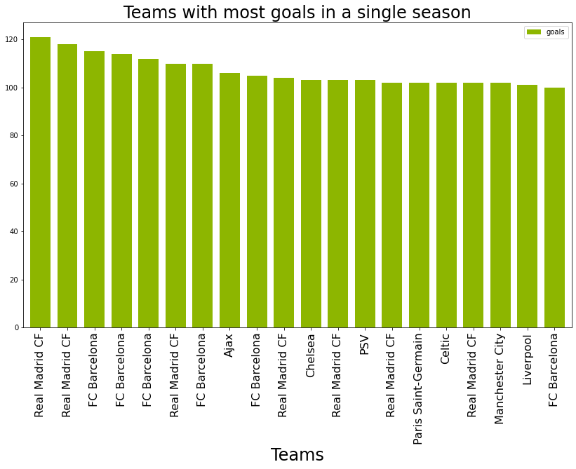

```python
team_season_goals.head(20).plot(x = 'team', y = 'goals', figsize = (14,8),width = 0.75, kind='bar', color = '#8DB600')
plt_attr('Teams','Teams with most goals in a single season')
```

#### The bar graph shows total number of goals scorred by teams in different seasons.

```python
team_season_goals.to_csv('team_season_goals.csv')
```

```python
team_goals = team_season_goals.groupby('team', as_index = False).sum('goals').sort_values(by = 'goals', ascending = False)
```

# Most goals scored by a team

```python
team_goals.head(20)
```

|  | team | goals |
| --- | --- | --- |
| 75 | FC Barcelona | 849 |
| 211 | Real Madrid CF | 843 |
| 49 | Celtic | 695 |
| 77 | FC Bayern Munich | 653 |
| 184 | PSV | 652 |
| 15 | Ajax | 647 |
| 76 | FC Basel | 619 |
| 161 | Manchester City | 606 |
| 51 | Chelsea | 583 |
| 162 | Manchester United | 582 |
| 19 | Arsenal | 573 |
| 186 | Paris Saint-Germain | 568 |
| 232 | SL Benfica | 568 |
| 34 | Borussia Dortmund | 551 |
| 133 | Juventus | 543 |
| 89 | FC Porto | 541 |
| 158 | Liverpool | 531 |
| 219 | Roma | 530 |
| 24 | BSC Young Boys | 529 |
| 23 | Atlético Madrid | 524 |

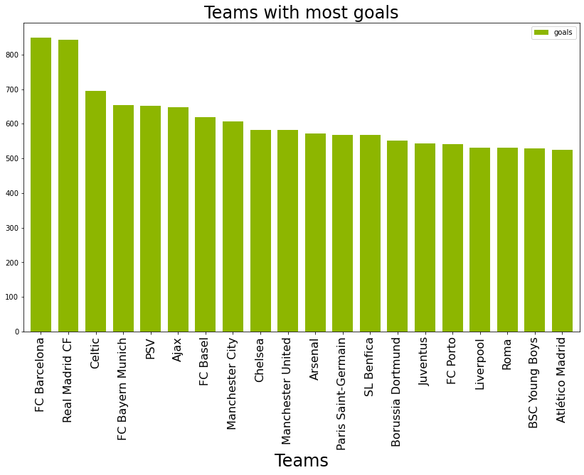

```python
team_goals.head(20).plot(x = 'team', y = 'goals', figsize = (14,8),width = 0.75, kind='bar', color = '#8DB600')
plt_attr('Teams','Teams with most goals');
```

#### The bar graph shows total number of goals scorred by teams in all seasons.

```python
season_goals = team_season_goals.groupby('season', as_index = False).sum('goals').sort_values(by = 'goals', ascending = False)
```

# Total goals scored per season

#### A table been created with total goals socred in each season among all leagues

> With season 2015/2016 with most goals 9162

```python
season_goals
```

|  | season | goals |
| --- | --- | --- |
| 7 | 2015/2016 | 9162 |
| 4 | 2012/2013 | 9039 |
| 6 | 2014/2015 | 8897 |
| 2 | 2010/2011 | 8749 |
| 3 | 2011/2012 | 8747 |
| 0 | 2008/2009 | 8672 |
| 1 | 2009/2010 | 8632 |
| 5 | 2013/2014 | 8389 |

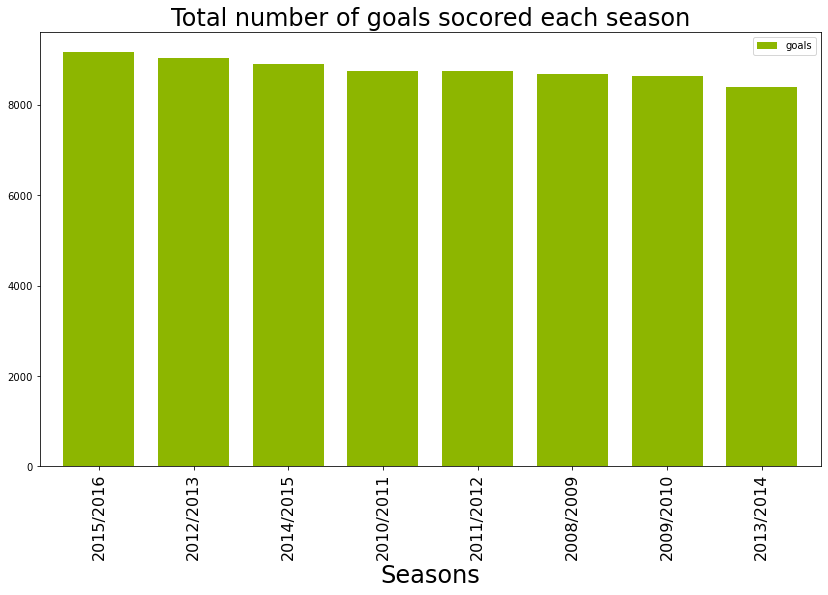

```python
season_goals.head(20).plot(x = 'season', y = 'goals', figsize = (14,8),width = 0.75, kind='bar', color = '#8DB600')
plt_attr('Seasons','Total number of goals socored each season')
```

#### The bar graph shows total number of goals scorred in different seasons.

```python
season_goals.to_csv('season_goals.csv')
```

```python
league_goals = team_season_goals.groupby('league_name', as_index = False).sum('goals').sort_values(by = 'goals', ascending = False)
```

# Total goals scored by league

#### A table been created with total goals socred in each league for all seasons

> With 'Spain LIGA BBVA' league with most goals 8412

```python
league_goals
```

|  | league_name | goals |
| --- | --- | --- |
| 9 | Spain LIGA BBVA | 8412 |
| 1 | England Premier League | 8240 |
| 4 | Italy Serie A | 7895 |
| 5 | Netherlands Eredivisie | 7542 |
| 2 | France Ligue 1 | 7427 |
| 3 | Germany 1. Bundesliga | 7103 |
| 7 | Portugal Liga ZON Sagres | 5201 |
| 0 | Belgium Jupiler League | 4841 |
| 8 | Scotland Premier League | 4804 |
| 6 | Poland Ekstraklasa | 4656 |
| 10 | Switzerland Super League | 4166 |

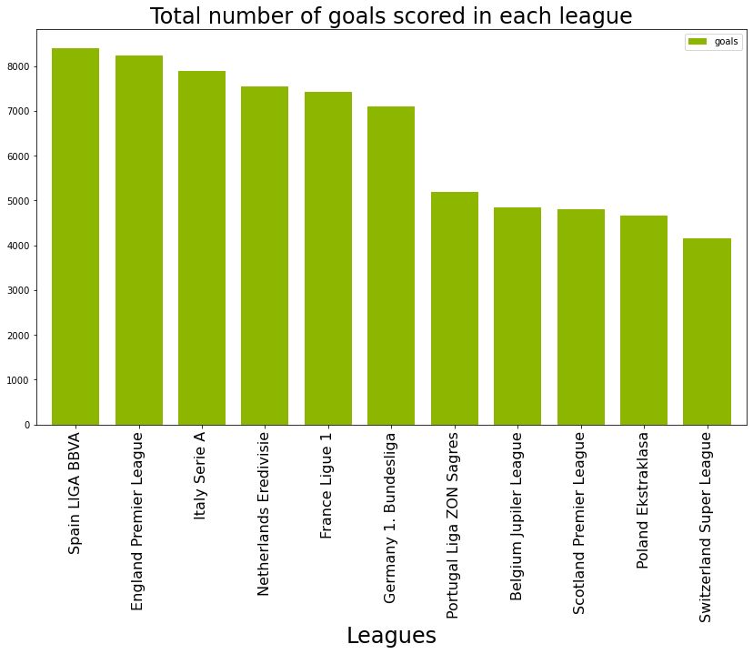

```python
league_goals.head(20).plot(x = 'league_name', y = 'goals', figsize = (14,8),width = 0.75, kind='bar', color = '#8DB600')
plt_attr('Leagues','Total number of goals scored in each league')
```

#### The bar graph shows total number of goals scorred in different leagues.

```python
league_goals.to_csv('league_goals.csv')
```

```python
team_season_goals
```

|  | season | league_name | team | goals |
| --- | --- | --- | --- | --- |
| 1 | 2011/2012 | Spain LIGA BBVA | Real Madrid CF | 121 |
| 6 | 2014/2015 | Spain LIGA BBVA | Real Madrid CF | 118 |
| 11 | 2012/2013 | Spain LIGA BBVA | FC Barcelona | 115 |
| 0 | 2011/2012 | Spain LIGA BBVA | FC Barcelona | 114 |
| 4 | 2015/2016 | Spain LIGA BBVA | FC Barcelona | 112 |
| ... | ... | ... | ... | ... |
| 1463 | 2008/2009 | Poland Ekstraklasa | Piast Gliwice | 17 |
| 1474 | 2013/2014 | Belgium Jupiler League | KAA Gent | 11 |
| 1476 | 2013/2014 | Belgium Jupiler League | Waasland-Beveren | 7 |
| 1477 | 2013/2014 | Belgium Jupiler League | KV Oostende | 7 |
| 1475 | 2013/2014 | Belgium Jupiler League | Lierse SK | 5 |

1478 rows × 4 columns

```python
team_improve = pd.pivot(team_season_goals, columns='season', index=['league_name', 'team'], values='goals')
team_improve.head()
```

| league_name | season team | 2008/2009 | 2009/2010 | 2010/2011 | 2011/2012 | 2012/2013 | 2013/2014 | 2014/2015 | 2015/2016 |
| --- | --- | --- | --- | --- | --- | --- | --- | --- | --- |
| Belgium Jupiler League | Beerschot AC | 44.0 | 30.0 | 24.0 | 45.0 | 31.0 | NaN | NaN | NaN |
|  | Club Brugge KV | 59.0 | 52.0 | 60.0 | 51.0 | 66.0 | NaN | 69.0 | 64.0 |
|  | FCV Dender EH | 44.0 | NaN | NaN | NaN | NaN | NaN | NaN | NaN |
|  | KAA Gent | 67.0 | 49.0 | 59.0 | 63.0 | 33.0 | 11.0 | 52.0 | 56.0 |
|  | KAS Eupen | NaN | NaN | 28.0 | NaN | NaN | NaN | NaN | NaN |

```python
team_improve.info()
```

```
<class 'pandas.core.frame.DataFrame'>
MultiIndex: 296 entries, ('Belgium Jupiler League', 'Beerschot AC') to ('Switzerland Super League', 'Servette FC')
Data columns (total 8 columns):
 #   Column     Non-Null Count  Dtype
---  ------     --------------  -----
 0   2008/2009  187 non-null    float64
 1   2009/2010  185 non-null    float64
 2   2010/2011  185 non-null    float64
 3   2011/2012  185 non-null    float64
 4   2012/2013  186 non-null    float64
 5   2013/2014  174 non-null    float64
 6   2014/2015  188 non-null    float64
 7   2015/2016  188 non-null    float64
dtypes: float64(8)
memory usage: 30.3+ KB
```

```python
float_columns = ['2008/2009','2009/2010','2010/2011','2011/2012','2012/2013','2013/2014','2014/2015','2015/2016']
for x in float_columns:
    team_improve[x] = team_improve[x].astype('Int32')
```

```python
team_improve.info()
```

```
<class 'pandas.core.frame.DataFrame'>
MultiIndex: 296 entries, ('Belgium Jupiler League', 'Beerschot AC') to ('Switzerland Super League', 'Servette FC')
Data columns (total 8 columns):
 #   Column     Non-Null Count  Dtype
---  ------     --------------  -----
 0   2008/2009  187 non-null    Int32
 1   2009/2010  185 non-null    Int32
 2   2010/2011  185 non-null    Int32
 3   2011/2012  185 non-null    Int32
 4   2012/2013  186 non-null    Int32
 5   2013/2014  174 non-null    Int32
 6   2014/2015  188 non-null    Int32
 7   2015/2016  188 non-null    Int32
dtypes: Int32(8)
memory usage: 23.3+ KB
```

```python
team_improve = team_improve.dropna()
team_improve['differnce'] = team_improve['2015/2016'] - team_improve['2008/2009']
team_improve = team_improve.sort_values(by = 'differnce', ascending = False).head(8)
```

> To find team improvement progress we converted team goals table into wide table with seasons as coulmns and teams as rows and checked the data types and turns out to be floats number and goals don't need to be float, so I converted all the columns into ints datatype, and some rows has na result for some seasons which could means that team has been relegated into lower tier league in that year so I choose to drop all clubs with na values to maintain data integrity, and then we calculated how much each team scored in first and last season and find the difference between them.

```python
team_improve.to_csv('team_improve.csv')
```

```python
team_improve = pd.read_csv('team_improve.csv')
```

# Best improved team in scoring goals

#### A table been created with difference between total goals scored in season 2008/2009 and season 2015/2016 to find the team improved in scoring goals the most between those 2 seasons and *'Paris Saint-Germain'* came first among these teams with 53 more golas scored (Over the double of number goals).

```python
team_improve
```

|  | league_name | team | 2008/2009 | 2009/2010 | 2010/2011 | 2011/2012 | 2012/2013 | 2013/2014 | 2014/2015 | 2015/2016 | differnce |
| --- | --- | --- | --- | --- | --- | --- | --- | --- | --- | --- | --- |
| 0 | France Ligue 1 | Paris Saint-Germain | 49 | 50 | 56 | 75 | 69 | 84 | 83 | 102 | 53 |
| 1 | Italy Serie A | Napoli | 43 | 50 | 59 | 64 | 73 | 77 | 68 | 80 | 37 |
| 2 | Portugal Liga ZON Sagres | Sporting CP | 45 | 42 | 41 | 47 | 36 | 54 | 67 | 79 | 34 |
| 3 | Portugal Liga ZON Sagres | SL Benfica | 54 | 78 | 61 | 66 | 77 | 58 | 86 | 88 | 34 |
| 4 | Germany 1. Bundesliga | Borussia Mönchengladbach | 39 | 43 | 48 | 49 | 45 | 59 | 53 | 67 | 28 |
| 5 | Spain LIGA BBVA | Real Madrid CF | 83 | 102 | 102 | 121 | 103 | 104 | 118 | 110 | 27 |
| 6 | England Premier League | Tottenham Hotspur | 45 | 67 | 55 | 66 | 66 | 55 | 58 | 69 | 24 |
| 7 | Portugal Liga ZON Sagres | Rio Ave FC | 20 | 22 | 35 | 33 | 35 | 21 | 38 | 44 | 24 |

[figure not shown]

```python
best_teams = goal_home_away_league.copy()
```

> To calculate the cound of teams win we reuse best_teams table with only differnce that we going to drop all draw results since we not going to need it to calculate most wins and then count every team wins and drop repeated and unnecessary columns and rename tables for readability.

```python
best_teams = best_teams[best_teams.winner != 'Draw']
best_teams.head()
```

|  | league_name | season | home_team | away_team | home_team_goal | away_team_goal | winner |
| --- | --- | --- | --- | --- | --- | --- | --- |
| 2 | Belgium Jupiler League | 2010/2011 | KRC Genk | Beerschot AC | 2 | 1 | KRC Genk |
| 3 | Belgium Jupiler League | 2011/2012 | KRC Genk | Beerschot AC | 3 | 1 | KRC Genk |
| 4 | Belgium Jupiler League | 2012/2013 | KRC Genk | Beerschot AC | 3 | 0 | KRC Genk |
| 6 | Belgium Jupiler League | 2009/2010 | SV Zulte-Waregem | Beerschot AC | 4 | 0 | SV Zulte-Waregem |
| 7 | Belgium Jupiler League | 2010/2011 | SV Zulte-Waregem | Beerschot AC | 4 | 3 | SV Zulte-Waregem |

```python
best_teams = best_teams.groupby('winner', as_index = False).count().sort_values(by='league_name', ascending = False)
best_teams
```

|  | winner | league_name | season | home_team | away_team | home_team_goal | away_team_goal |
| --- | --- | --- | --- | --- | --- | --- | --- |
| 75 | FC Barcelona | 234 | 234 | 234 | 234 | 234 | 234 |
| 211 | Real Madrid CF | 228 | 228 | 228 | 228 | 228 | 228 |
| 49 | Celtic | 218 | 218 | 218 | 218 | 218 | 218 |
| 77 | FC Bayern Munich | 193 | 193 | 193 | 193 | 193 | 193 |
| 162 | Manchester United | 192 | 192 | 192 | 192 | 192 | 192 |
| ... | ... | ... | ... | ... | ... | ... | ... |
| 57 | DSC Arminia Bielefeld | 4 | 4 | 4 | 4 | 4 | 4 |
| 78 | FC Dordrecht | 4 | 4 | 4 | 4 | 4 | 4 |
| 244 | SpVgg Greuther Fürth | 4 | 4 | 4 | 4 | 4 | 4 |
| 56 | Córdoba CF | 3 | 3 | 3 | 3 | 3 | 3 |
| 5 | AC Arles-Avignon | 3 | 3 | 3 | 3 | 3 | 3 |

296 rows × 7 columns

```python
best_teams.drop(['season','home_team','away_team','home_team_goal','away_team_goal'], inplace = True, axis = 1)
best_teams.rename(columns = {'winner':'team', 'league_name':'wins'}, inplace = True)
best_teams = best_teams.head(10)
```

### Teams with most wins

```python
best_teams
```

|  | team | wins |
| --- | --- | --- |
| 75 | FC Barcelona | 234 |
| 211 | Real Madrid CF | 228 |
| 49 | Celtic | 218 |
| 77 | FC Bayern Munich | 193 |
| 162 | Manchester United | 192 |
| 133 | Juventus | 189 |
| 232 | SL Benfica | 185 |
| 89 | FC Porto | 183 |
| 15 | Ajax | 181 |
| 76 | FC Basel | 180 |

```python
best_teams = pd.merge(left = team, right = best_teams, left_on = 'team_long_name', right_on = 'team')
best_teams
```

|  | team_api_id | team_long_name | team | wins |
| --- | --- | --- | --- | --- |
| 0 | 10260 | Manchester United | Manchester United | 192 |
| 1 | 9823 | FC Bayern Munich | FC Bayern Munich | 193 |
| 2 | 9885 | Juventus | Juventus | 189 |
| 3 | 8593 | Ajax | Ajax | 181 |
| 4 | 9773 | FC Porto | FC Porto | 183 |
| 5 | 9772 | SL Benfica | SL Benfica | 185 |
| 6 | 9925 | Celtic | Celtic | 218 |
| 7 | 8633 | Real Madrid CF | Real Madrid CF | 228 |
| 8 | 8634 | FC Barcelona | FC Barcelona | 234 |
| 9 | 9931 | FC Basel | FC Basel | 180 |

```python
best_teams.drop(['team_long_name','wins'], axis = 1, inplace = True)
best_teams
```

|  | team_api_id | team |
| --- | --- | --- |
| 0 | 10260 | Manchester United |
| 1 | 9823 | FC Bayern Munich |
| 2 | 9885 | Juventus |
| 3 | 8593 | Ajax |
| 4 | 9773 | FC Porto |
| 5 | 9772 | SL Benfica |
| 6 | 9925 | Celtic |
| 7 | 8633 | Real Madrid CF |
| 8 | 8634 | FC Barcelona |
| 9 | 9931 | FC Basel |

```python
team_attributes = pd.read_csv('team_attributes.csv')
team_attributes.head()
```

|  | id | team_fifa_api_id | team_api_id | date | buildUpPlaySpeed | buildUpPlaySpeedClass | buildUpPlayDribbling | buildUpPlayDribblingClass | buildUpPlayPassing | buildUpPlayPassingClass | ... | chanceCreationShooting | chanceCreationShootingClass | chanceCreationPositioningClass | defencePressure | defencePressureClass | defenceAggression | defenceAggressionClass | defenceTeamWidth | defenceTeamWidthClass | defenceDefenderLineClass |
| --- | --- | --- | --- | --- | --- | --- | --- | --- | --- | --- | --- | --- | --- | --- | --- | --- | --- | --- | --- | --- | --- |
| 0 | 1 | 434 | 9930 | 2010-02-22 00:00:00 | 60 | Balanced | NaN | Little | 50 | Mixed | ... | 55 | Normal | Organised | 50 | Medium | 55 | Press | 45 | Normal | Cover |
| 1 | 2 | 434 | 9930 | 2014-09-19 00:00:00 | 52 | Balanced | 48.0 | Normal | 56 | Mixed | ... | 64 | Normal | Organised | 47 | Medium | 44 | Press | 54 | Normal | Cover |
| 2 | 3 | 434 | 9930 | 2015-09-10 00:00:00 | 47 | Balanced | 41.0 | Normal | 54 | Mixed | ... | 64 | Normal | Organised | 47 | Medium | 44 | Press | 54 | Normal | Cover |
| 3 | 4 | 77 | 8485 | 2010-02-22 00:00:00 | 70 | Fast | NaN | Little | 70 | Long | ... | 70 | Lots | Organised | 60 | Medium | 70 | Double | 70 | Wide | Cover |
| 4 | 5 | 77 | 8485 | 2011-02-22 00:00:00 | 47 | Balanced | NaN | Little | 52 | Mixed | ... | 52 | Normal | Organised | 47 | Medium | 47 | Press | 52 | Normal | Cover |

5 rows × 25 columns

```python
team_attributes.info()
```

```
<class 'pandas.core.frame.DataFrame'>
RangeIndex: 1458 entries, 0 to 1457
Data columns (total 25 columns):
 #   Column                          Non-Null Count  Dtype
---  ------                          --------------  -----
 0   id                              1458 non-null   int64
 1   team_fifa_api_id                1458 non-null   int64
 2   team_api_id                     1458 non-null   int64
 3   date                            1458 non-null   object
 4   buildUpPlaySpeed                1458 non-null   int64
 5   buildUpPlaySpeedClass           1458 non-null   object
 6   buildUpPlayDribbling            489 non-null    float64
 7   buildUpPlayDribblingClass       1458 non-null   object
 8   buildUpPlayPassing              1458 non-null   int64
 9   buildUpPlayPassingClass         1458 non-null   object
```

[output cut: 17 more lines]

> With team attributes table we only need numeric team attributes values so we drop all object/string columns and then find the average attribute rating for each team based on all matches played and round the number to 2 decimal places for convenience and then 'lef merge' the table with best teams table since we only want to see what the best teams have in commen not what all teams have on common.

```python
team_attributes.drop(['id','team_fifa_api_id','date','buildUpPlaySpeedClass','buildUpPlayDribblingClass',
                      'buildUpPlayPassingClass','buildUpPlayPositioningClass','chanceCreationPassingClass','chanceCreationCrossingClass',
                     'chanceCreationShootingClass','chanceCreationPositioningClass','defencePressureClass','defenceAggressionClass',
                      'defenceTeamWidthClass','defenceDefenderLineClass'], axis = 1, inplace = True)
team_attributes = round(team_attributes.groupby('team_api_id').mean(), 2)
team_attributes
```

| team_api_id | buildUpPlaySpeed | buildUpPlayDribbling | buildUpPlayPassing | chanceCreationPassing | chanceCreationCrossing | chanceCreationShooting | defencePressure | defenceAggression | defenceTeamWidth |
| --- | --- | --- | --- | --- | --- | --- | --- | --- | --- |
| 1601 | 47.33 | 48.0 | 46.17 | 55.50 | 60.33 | 53.50 | 47.17 | 47.33 | 49.33 |
| 1773 | 52.00 | 51.0 | 50.00 | 50.00 | 53.00 | 54.00 | 43.00 | 44.00 | 50.00 |
| 1957 | 47.17 | 54.0 | 52.67 | 50.83 | 36.33 | 67.00 | 49.33 | 56.33 | 53.67 |
| 2033 | 49.00 | 62.0 | 48.40 | 51.80 | 44.20 | 48.20 | 42.20 | 33.80 | 45.40 |
| 2182 | 60.33 | 52.5 | 49.00 | 56.67 | 57.33 | 68.00 | 51.67 | 48.50 | 54.50 |
| ... | ... | ... | ... | ... | ... | ... | ... | ... | ... |
| 10281 | 52.83 | 42.0 | 53.67 | 50.33 | 59.17 | 50.33 | 45.50 | 51.17 | 52.67 |
| 108893 | 43.17 | 47.0 | 53.17 | 46.00 | 38.33 | 39.50 | 38.33 | 46.00 | 46.33 |
| 158085 | 67.00 | 66.0 | 39.00 | 55.00 | 59.00 | 46.00 | 36.00 | 38.00 | 37.00 |
| 208931 | 56.00 | 45.5 | 48.00 | 58.50 | 38.00 | 52.00 | 35.50 | 49.50 | 43.00 |
| 274581 | 50.00 | 50.0 | 50.00 | 50.00 | 50.00 | 50.00 | 45.00 | 45.00 | 50.00 |

288 rows × 9 columns

```python
team_attributes.info()
```

```
<class 'pandas.core.frame.DataFrame'>
Int64Index: 288 entries, 1601 to 274581
Data columns (total 9 columns):
 #   Column                  Non-Null Count  Dtype
---  ------                  --------------  -----
 0   buildUpPlaySpeed        288 non-null    float64
 1   buildUpPlayDribbling    262 non-null    float64
 2   buildUpPlayPassing      288 non-null    float64
 3   chanceCreationPassing   288 non-null    float64
 4   chanceCreationCrossing  288 non-null    float64
 5   chanceCreationShooting  288 non-null    float64
 6   defencePressure         288 non-null    float64
 7   defenceAggression       288 non-null    float64
 8   defenceTeamWidth        288 non-null    float64
dtypes: float64(9)
memory usage: 22.5 KB
```

```python
team_attributes = round(team_attributes.groupby('team_api_id').mean(), 2)
team_attributes
```

| team_api_id | buildUpPlaySpeed | buildUpPlayDribbling | buildUpPlayPassing | chanceCreationPassing | chanceCreationCrossing | chanceCreationShooting | defencePressure | defenceAggression | defenceTeamWidth |
| --- | --- | --- | --- | --- | --- | --- | --- | --- | --- |
| 1601 | 47.33 | 48.0 | 46.17 | 55.50 | 60.33 | 53.50 | 47.17 | 47.33 | 49.33 |
| 1773 | 52.00 | 51.0 | 50.00 | 50.00 | 53.00 | 54.00 | 43.00 | 44.00 | 50.00 |
| 1957 | 47.17 | 54.0 | 52.67 | 50.83 | 36.33 | 67.00 | 49.33 | 56.33 | 53.67 |
| 2033 | 49.00 | 62.0 | 48.40 | 51.80 | 44.20 | 48.20 | 42.20 | 33.80 | 45.40 |
| 2182 | 60.33 | 52.5 | 49.00 | 56.67 | 57.33 | 68.00 | 51.67 | 48.50 | 54.50 |
| ... | ... | ... | ... | ... | ... | ... | ... | ... | ... |
| 10281 | 52.83 | 42.0 | 53.67 | 50.33 | 59.17 | 50.33 | 45.50 | 51.17 | 52.67 |
| 108893 | 43.17 | 47.0 | 53.17 | 46.00 | 38.33 | 39.50 | 38.33 | 46.00 | 46.33 |
| 158085 | 67.00 | 66.0 | 39.00 | 55.00 | 59.00 | 46.00 | 36.00 | 38.00 | 37.00 |
| 208931 | 56.00 | 45.5 | 48.00 | 58.50 | 38.00 | 52.00 | 35.50 | 49.50 | 43.00 |
| 274581 | 50.00 | 50.0 | 50.00 | 50.00 | 50.00 | 50.00 | 45.00 | 45.00 | 50.00 |

288 rows × 9 columns

```python
best_teams_attr = pd.merge(left = best_teams, right = team_attributes, how = 'left', left_on = 'team_api_id', right_on = 'team_api_id')
```

# Best teams attributes on average

#### A table been created with top 10 teams with most wins average attributes, and each team has different playing style and there is no single attribute can be linked to winning, but 'defence Aggression' attribute is the most consistant one on average among the best teams

```python
best_teams_attr
```

|  | team_api_id | team | buildUpPlaySpeed | buildUpPlayDribbling | buildUpPlayPassing | chanceCreationPassing | chanceCreationCrossing | chanceCreationShooting | defencePressure | defenceAggression | defenceTeamWidth |
| --- | --- | --- | --- | --- | --- | --- | --- | --- | --- | --- | --- |
| 0 | 10260 | Manchester United | 51.83 | 38.0 | 45.83 | 50.00 | 63.17 | 53.83 | 45.00 | 48.00 | 54.83 |
| 1 | 9823 | FC Bayern Munich | 48.67 | 29.0 | 35.17 | 38.50 | 40.67 | 49.67 | 57.17 | 48.83 | 55.17 |
| 2 | 9885 | Juventus | 45.83 | 41.0 | 32.83 | 56.67 | 60.50 | 65.67 | 44.00 | 57.33 | 41.17 |
| 3 | 8593 | Ajax | 35.17 | 41.5 | 33.83 | 50.67 | 58.50 | 49.67 | 59.83 | 53.83 | 54.33 |
| 4 | 9773 | FC Porto | 51.00 | 50.0 | 48.67 | 55.67 | 66.83 | 66.17 | 53.33 | 50.33 | 55.33 |
| 5 | 9772 | SL Benfica | 59.00 | 55.0 | 45.50 | 63.83 | 59.00 | 55.33 | 54.33 | 51.50 | 52.00 |
| 6 | 9925 | Celtic | 61.33 | 50.5 | 57.33 | 55.67 | 60.83 | 60.83 | 53.33 | 54.33 | 62.17 |
| 7 | 8633 | Real Madrid CF | 50.67 | 55.5 | 38.67 | 67.50 | 53.83 | 69.00 | 52.00 | 52.17 | 63.50 |
| 8 | 8634 | FC Barcelona | 35.83 | 35.0 | 34.00 | 45.17 | 33.33 | 53.00 | 64.33 | 54.50 | 66.50 |
| 9 | 9931 | FC Basel | 55.00 | 63.0 | 44.83 | 60.83 | 63.83 | 52.50 | 47.67 | 57.50 | 54.50 |

[figure not shown]

> Line graph shows average attributes for best teams in european leagues based on number of wins

```python
best_teams_attr.to_csv('best_teams_attr.csv')
```

> we use the goals table again but this time to find the teams with home or away win and count the wins either home or away and drop unnecessary columns and rearrange table coulmns for convenience.

```python
conditions = [goal_home_away['home_team_goal'] > goal_home_away['away_team_goal'],
              goal_home_away['home_team_goal'] < goal_home_away['away_team_goal']]
choices = ['home_team','away_team']
goal_home_away['winner'] = np.select(conditions, choices, default = 'Draw')

goal_home_away.head()
```

|  | league_id | season | home_team_api_id | away_team_api_id | home_team_goal | away_team_goal | home_team | away_team | winner |
| --- | --- | --- | --- | --- | --- | --- | --- | --- | --- |
| 0 | 1 | 2008/2009 | 9987 | 9993 | 1 | 1 | KRC Genk | Beerschot AC | Draw |
| 1 | 1 | 2009/2010 | 9987 | 9993 | 1 | 1 | KRC Genk | Beerschot AC | Draw |
| 2 | 1 | 2010/2011 | 9987 | 9993 | 2 | 1 | KRC Genk | Beerschot AC | home_team |
| 3 | 1 | 2011/2012 | 9987 | 9993 | 3 | 1 | KRC Genk | Beerschot AC | home_team |
| 4 | 1 | 2012/2013 | 9987 | 9993 | 3 | 0 | KRC Genk | Beerschot AC | home_team |

```python
win_home_away_teams = pd.merge(left=goal_home_away, right=league, left_on='league_id', right_on='country_id')
win_home_away_teams.head()
```

|  | league_id | season | home_team_api_id | away_team_api_id | home_team_goal | away_team_goal | home_team | away_team | winner | country_id | league_name |
| --- | --- | --- | --- | --- | --- | --- | --- | --- | --- | --- | --- |
| 0 | 1 | 2008/2009 | 9987 | 9993 | 1 | 1 | KRC Genk | Beerschot AC | Draw | 1 | Belgium Jupiler League |
| 1 | 1 | 2009/2010 | 9987 | 9993 | 1 | 1 | KRC Genk | Beerschot AC | Draw | 1 | Belgium Jupiler League |
| 2 | 1 | 2010/2011 | 9987 | 9993 | 2 | 1 | KRC Genk | Beerschot AC | home_team | 1 | Belgium Jupiler League |
| 3 | 1 | 2011/2012 | 9987 | 9993 | 3 | 1 | KRC Genk | Beerschot AC | home_team | 1 | Belgium Jupiler League |
| 4 | 1 | 2012/2013 | 9987 | 9993 | 3 | 0 | KRC Genk | Beerschot AC | home_team | 1 | Belgium Jupiler League |

```python
win_home_away = win_home_away_teams.copy()
```

```python
win_home_away.drop(['league_id', 'home_team_api_id', 'away_team_api_id', 'country_id'],axis = 1, inplace = True)
win_home_away.head()
```

|  | season | home_team_goal | away_team_goal | home_team | away_team | winner | league_name |
| --- | --- | --- | --- | --- | --- | --- | --- |
| 0 | 2008/2009 | 1 | 1 | KRC Genk | Beerschot AC | Draw | Belgium Jupiler League |
| 1 | 2009/2010 | 1 | 1 | KRC Genk | Beerschot AC | Draw | Belgium Jupiler League |
| 2 | 2010/2011 | 2 | 1 | KRC Genk | Beerschot AC | home_team | Belgium Jupiler League |
| 3 | 2011/2012 | 3 | 1 | KRC Genk | Beerschot AC | home_team | Belgium Jupiler League |
| 4 | 2012/2013 | 3 | 0 | KRC Genk | Beerschot AC | home_team | Belgium Jupiler League |

```python
win_home_away = win_home_away.reindex(columns = ['league_name', 'season', 'home_team', 'away_team',
                                                 'home_team_goal', 'away_team_goal','winner'])
win_home_away.head()
```

|  | league_name | season | home_team | away_team | home_team_goal | away_team_goal | winner |
| --- | --- | --- | --- | --- | --- | --- | --- |
| 0 | Belgium Jupiler League | 2008/2009 | KRC Genk | Beerschot AC | 1 | 1 | Draw |
| 1 | Belgium Jupiler League | 2009/2010 | KRC Genk | Beerschot AC | 1 | 1 | Draw |
| 2 | Belgium Jupiler League | 2010/2011 | KRC Genk | Beerschot AC | 2 | 1 | home_team |
| 3 | Belgium Jupiler League | 2011/2012 | KRC Genk | Beerschot AC | 3 | 1 | home_team |
| 4 | Belgium Jupiler League | 2012/2013 | KRC Genk | Beerschot AC | 3 | 0 | home_team |

```python
win_home_away = win_home_away.groupby(['league_name', 'winner'], as_index = False).count()
```

```python
win_home_away.head(6)
```

|  | league_name | winner | season | home_team | away_team | home_team_goal | away_team_goal |
| --- | --- | --- | --- | --- | --- | --- | --- |
| 0 | Belgium Jupiler League | Draw | 425 | 425 | 425 | 425 | 425 |
| 1 | Belgium Jupiler League | away_team | 493 | 493 | 493 | 493 | 493 |
| 2 | Belgium Jupiler League | home_team | 810 | 810 | 810 | 810 | 810 |
| 3 | England Premier League | Draw | 783 | 783 | 783 | 783 | 783 |
| 4 | England Premier League | away_team | 867 | 867 | 867 | 867 | 867 |
| 5 | England Premier League | home_team | 1390 | 1390 | 1390 | 1390 | 1390 |

## Ratio of home to away wins in different leagues

```python
win_home_away.drop(['home_team','away_team','home_team_goal','away_team_goal'], axis = 1, inplace = True)
win_home_away.rename(columns = {'season':'total'}, inplace = True)
win_home_away
```

|  | league_name | winner | total |
| --- | --- | --- | --- |
| 0 | Belgium Jupiler League | Draw | 425 |
| 1 | Belgium Jupiler League | away_team | 493 |
| 2 | Belgium Jupiler League | home_team | 810 |
| 3 | England Premier League | Draw | 783 |
| 4 | England Premier League | away_team | 867 |
| 5 | England Premier League | home_team | 1390 |
| 6 | France Ligue 1 | Draw | 859 |
| 7 | France Ligue 1 | away_team | 822 |
| 8 | France Ligue 1 | home_team | 1359 |
| 9 | Germany 1. Bundesliga | Draw | 597 |
| 10 | Germany 1. Bundesliga | away_team | 744 |
| 11 | Germany 1. Bundesliga | home_team | 1107 |
| 12 | Italy Serie A | Draw | 796 |
| 13 | Italy Serie A | away_team | 814 |
| 14 | Italy Serie A | home_team | 1407 |
| 15 | Netherlands Eredivisie | Draw | 581 |
| 16 | Netherlands Eredivisie | away_team | 696 |
| 17 | Netherlands Eredivisie | home_team | 1171 |
| 18 | Poland Ekstraklasa | Draw | 525 |
| 19 | Poland Ekstraklasa | away_team | 525 |
| 20 | Poland Ekstraklasa | home_team | 870 |
| 21 | Portugal Liga ZON Sagres | Draw | 533 |
| 22 | Portugal Liga ZON Sagres | away_team | 611 |
| 23 | Portugal Liga ZON Sagres | home_team | 908 |
| 24 | Scotland Premier League | Draw | 447 |
| 25 | Scotland Premier League | away_team | 617 |
| 26 | Scotland Premier League | home_team | 760 |
| 27 | Spain LIGA BBVA | Draw | 704 |
| 28 | Spain LIGA BBVA | away_team | 851 |
| 29 | Spain LIGA BBVA | home_team | 1485 |
| 30 | Switzerland Super League | Draw | 346 |
| 31 | Switzerland Super League | away_team | 426 |
| 32 | Switzerland Super League | home_team | 650 |

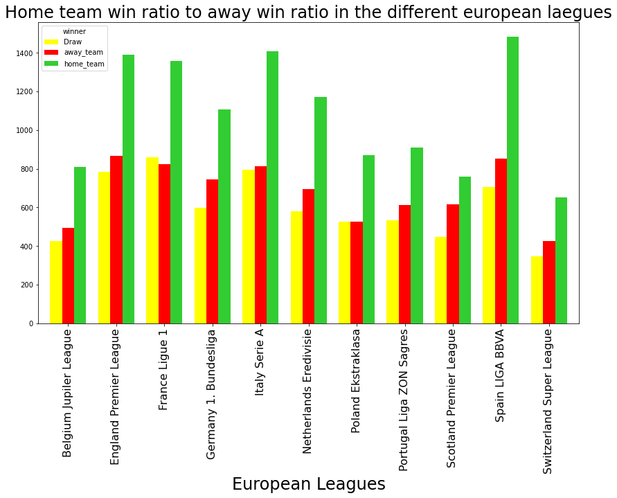

```python
win_home_away.pivot('league_name', 'winner', 'total').plot(color = ['yellow', 'red', 'limegreen'], figsize = (14,8),width = 0.75, kind='bar')
plt_attr('European Leagues','Home team win ratio to away win ratio in the different european laegues')
```

```python
bigest_difference =  win_home_away.query('league_name == "Italy Serie A"')
least_difference = win_home_away.query('league_name == "Scotland Premier League"')
```

```python
least_difference
```

|  | league_name | winner | total |
| --- | --- | --- | --- |
| 24 | Scotland Premier League | Draw | 447 |
| 25 | Scotland Premier League | away_team | 617 |
| 26 | Scotland Premier League | home_team | 760 |

```python
bigest_difference
```

|  | league_name | winner | total |
| --- | --- | --- | --- |
| 12 | Italy Serie A | Draw | 796 |
| 13 | Italy Serie A | away_team | 814 |
| 14 | Italy Serie A | home_team | 1407 |

```python
labels = ['draw', 'away win', 'home win']
colors = ['yellow', 'red', 'green']
```

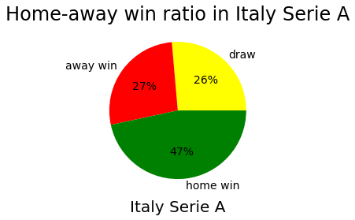

```python
plt.pie(bigest_difference['total'], labels = labels, colors = colors, autopct='%.0f%%',
        textprops={'fontsize': 14},radius = 1);
plt.xticks(fontsize=20)
plt.xlabel('Italy Serie A', fontsize = 20)
plt.title('Home-away win ratio in Italy Serie A', fontsize=24);
```

> Pie chart shows percentage of home-away win ration in Italy Serie A

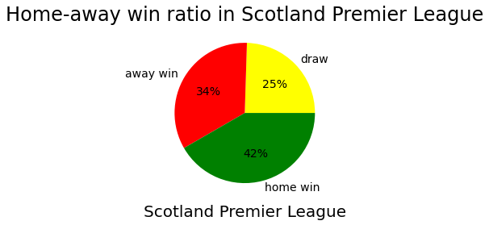

```python
plt.pie(least_difference['total'], labels = labels, colors = colors, autopct='%.0f%%',
        textprops={'fontsize': 14},radius = 1);
plt.xticks(fontsize=20)
plt.xlabel('Scotland Premier League', fontsize = 20)
plt.title('Home-away win ratio in Scotland Premier League', fontsize=24);
```

> Pie chart shows percentage of home-away win ration in Scotland Premier League

```python
win_home_away_teams.drop(['league_id', 'home_team_api_id', 'away_team_api_id', 'country_id','home_team_goal','away_team_goal'],axis = 1, inplace = True)
win_home_away_teams.head(20)
```

|  | season | home_team | away_team | winner | league_name |
| --- | --- | --- | --- | --- | --- |
| 0 | 2008/2009 | KRC Genk | Beerschot AC | Draw | Belgium Jupiler League |
| 1 | 2009/2010 | KRC Genk | Beerschot AC | Draw | Belgium Jupiler League |
| 2 | 2010/2011 | KRC Genk | Beerschot AC | home_team | Belgium Jupiler League |
| 3 | 2011/2012 | KRC Genk | Beerschot AC | home_team | Belgium Jupiler League |
| 4 | 2012/2013 | KRC Genk | Beerschot AC | home_team | Belgium Jupiler League |
| 5 | 2008/2009 | SV Zulte-Waregem | Beerschot AC | Draw | Belgium Jupiler League |
| 6 | 2009/2010 | SV Zulte-Waregem | Beerschot AC | home_team | Belgium Jupiler League |
| 7 | 2010/2011 | SV Zulte-Waregem | Beerschot AC | home_team | Belgium Jupiler League |
| 8 | 2011/2012 | SV Zulte-Waregem | Beerschot AC | home_team | Belgium Jupiler League |
| 9 | 2012/2013 | SV Zulte-Waregem | Beerschot AC | Draw | Belgium Jupiler League |
| 10 | 2008/2009 | KSV Cercle Brugge | Beerschot AC | home_team | Belgium Jupiler League |
| 11 | 2009/2010 | KSV Cercle Brugge | Beerschot AC | away_team | Belgium Jupiler League |
| 12 | 2010/2011 | KSV Cercle Brugge | Beerschot AC | Draw | Belgium Jupiler League |
| 13 | 2011/2012 | KSV Cercle Brugge | Beerschot AC | home_team | Belgium Jupiler League |
| 14 | 2012/2013 | KSV Cercle Brugge | Beerschot AC | home_team | Belgium Jupiler League |
| 15 | 2008/2009 | KAA Gent | Beerschot AC | away_team | Belgium Jupiler League |
| 16 | 2009/2010 | KAA Gent | Beerschot AC | away_team | Belgium Jupiler League |
| 17 | 2010/2011 | KAA Gent | Beerschot AC | home_team | Belgium Jupiler League |
| 18 | 2011/2012 | KAA Gent | Beerschot AC | away_team | Belgium Jupiler League |
| 19 | 2012/2013 | KAA Gent | Beerschot AC | home_team | Belgium Jupiler League |

```python
win_home_away_teams = win_home_away_teams[win_home_away_teams.winner != 'Draw']
win_home_away_teams.head()
```

|  | season | home_team | away_team | winner | league_name |
| --- | --- | --- | --- | --- | --- |
| 2 | 2010/2011 | KRC Genk | Beerschot AC | home_team | Belgium Jupiler League |
| 3 | 2011/2012 | KRC Genk | Beerschot AC | home_team | Belgium Jupiler League |
| 4 | 2012/2013 | KRC Genk | Beerschot AC | home_team | Belgium Jupiler League |
| 6 | 2009/2010 | SV Zulte-Waregem | Beerschot AC | home_team | Belgium Jupiler League |
| 7 | 2010/2011 | SV Zulte-Waregem | Beerschot AC | home_team | Belgium Jupiler League |

```python
win_home_away_teams = win_home_away_teams.groupby(['home_team', 'winner'], as_index = False).count()
win_home_away_teams
```

|  | home_team | winner | season | away_team | league_name |
| --- | --- | --- | --- | --- | --- |
| 0 | 1. FC Kaiserslautern | away_team | 15 | 15 | 15 |
| 1 | 1. FC Kaiserslautern | home_team | 8 | 8 | 8 |
| 2 | 1. FC Köln | away_team | 39 | 39 | 39 |
| 3 | 1. FC Köln | home_team | 32 | 32 | 32 |
| 4 | 1. FC Nürnberg | away_team | 34 | 34 | 34 |
| ... | ... | ... | ... | ... | ... |
| 586 | Zawisza Bydgoszcz | home_team | 13 | 13 | 13 |
| 587 | Évian Thonon Gaillard FC | away_team | 30 | 30 | 30 |
| 588 | Évian Thonon Gaillard FC | home_team | 29 | 29 | 29 |
| 589 | Śląsk Wrocław | away_team | 26 | 26 | 26 |
| 590 | Śląsk Wrocław | home_team | 59 | 59 | 59 |

591 rows × 5 columns

```python
win_home_away_teams.drop(['away_team', 'league_name'], axis = 1, inplace = True)
win_home_away_teams.rename(columns = {'winner':'win_as','season':'wins'}, inplace = True)
win_home_away_teams
```

|  | home_team | win_as | wins |
| --- | --- | --- | --- |
| 0 | 1. FC Kaiserslautern | away_team | 15 |
| 1 | 1. FC Kaiserslautern | home_team | 8 |
| 2 | 1. FC Köln | away_team | 39 |
| 3 | 1. FC Köln | home_team | 32 |
| 4 | 1. FC Nürnberg | away_team | 34 |
| ... | ... | ... | ... |
| 586 | Zawisza Bydgoszcz | home_team | 13 |
| 587 | Évian Thonon Gaillard FC | away_team | 30 |
| 588 | Évian Thonon Gaillard FC | home_team | 29 |
| 589 | Śląsk Wrocław | away_team | 26 |
| 590 | Śląsk Wrocław | home_team | 59 |

591 rows × 3 columns

```python
away_wins = win_home_away_teams[win_home_away_teams['win_as'] == 'away_team'].sort_values(by = 'wins', ascending = False)
away_wins.drop('win_as', inplace = True, axis = 1)
away_wins.rename(columns = {'wins':'away_wins'},inplace = True)
```